# Relationship Between Gasoline and Crude Oil Prices

Zak Ahmad

May 23, 2015

Recently, a colleague told me he doesn’t seem to that gas prices are affected by oil prices. So the data savvy person in me decided to take a look into it.

# The Data

FRED (Federal Reserve Economic Data of St. Louis Fed) has historical data for WTI Crude Oil and average Gasoline prices. The gasoline prices, averaged from roughly 900 retail outlets, are reported weekly at 8:00AM every Monday. As for crude oil, FRED does have daily data but I will use the weekly data reported every Friday since the gas prices are weekly.

A copy of the data in csv form is in the github repository for this post along with R code used for the analysis.

# Prepping the Data

Let’s read the data into dataframes and make sure the date and price data types are plausible. Also, we will compute the (weekly) percent change of price so this is also computed. Let’s look at the summary of the data

```r
# data files
gasFile <- 'gas-prices.csv'
usoFile <- 'wti-crude-oil-prices.csv'
# read data from files
gasDF <- read.csv(gasFile,stringsAsFactors=FALSE)
oilDF <- read.csv(usoFile,stringsAsFactors=FALSE)
# change Date data type from integer to Date
gasDF$DATE <- as.Date(gasDF$DATE)
oilDF$DATE <- as.Date(oilDF$DATE)
# change Prices data type numeric from char
gasDF$VALUE <- as.numeric(gasDF$VALUE)
oilDF$VALUE <- as.numeric(oilDF$VALUE)
# compute percent change
gasPctChg <- 100 * diff(gasDF$VALUE) / gasDF$VALUE[1:length(gasDF$VALUE) - 1]
oilPctChg <- 100 * diff(oilDF$VALUE) / oilDF$VALUE[1:length(oilDF$VALUE) - 1]
# delete first row since percent change is 1 row shorter
gasDF <- gasDF[-1,]
oilDF <- oilDF[-1,]
# Store percent change to DF
gasDF$PctChg <- gasPctChg
oilDF$PctChg <- oilPctChg
# print summary of gasoline data
summary(gasDF)
```

```
##       DATE                VALUE           PctChg
##  Min.   :1990-08-27   Min.   :0.907   Min.   :-9.63855
##  1st Qu.:1996-10-28   1st Qu.:1.129   1st Qu.:-0.82991
##  Median :2002-12-30   Median :1.536   Median :-0.09005
##  Mean   :2002-12-30   Mean   :1.986   Mean   : 0.09042
##  3rd Qu.:2009-03-02   3rd Qu.:2.800   3rd Qu.: 0.95069
##  Max.   :2015-05-04   Max.   :4.114   Max.   :17.58621
##                       NA's   :6       NA's   :7
```

```r
# print summary of crude oil data
summary(oilDF)
```

```
##       DATE                VALUE            PctChg
##  Min.   :1986-01-10   Min.   : 11.00   Min.   :-17.4972
##  1st Qu.:1993-05-07   1st Qu.: 19.13   1st Qu.: -2.3204
##  Median :2000-09-01   Median : 26.84   Median :  0.2210
##  Mean   :2000-09-01   Mean   : 42.77   Mean   :  0.1456
##  3rd Qu.:2007-12-28   3rd Qu.: 66.59   3rd Qu.:  2.5783
##  Max.   :2015-04-24   Max.   :142.52   Max.   : 28.5628
```

We see that the gas prices (and therefore the percent change) has NA’s so we’ll remove them.

```r
# remove rows with NAs
gasDF <- gasDF[complete.cases(gasDF),]
```

The easiest and quickest way to align both data sets is to merge them into a single dataframe by date. This brings us to the second issue with the dates. Oil prices are reported every Friday and gas prices every Monday. So if we were to merge the two prices by date we’ll end up with an empty dataframe!

One solution is to shift the dates of oil prices ahead by 3 days.

```r
# shift oil price dates by 3 days to align with gas dates
oilDF$DATE <- oilDF$DATE+3
```

Now we can merge them and rename some columns to something more descriptive than what is returned from the merge function.

```r
# merge oil and gas prices by date
oilgasDF <- merge(gasDF,oilDF,by="DATE",all.x=FALSE)
# rename columns to be more descriptive
colnames(oilgasDF)[2] <- "GasPrice"
colnames(oilgasDF)[3] <- "GasPctChg"
colnames(oilgasDF)[4] <- "OilPrice"
colnames(oilgasDF)[5] <- "OilPctChg"
```

# Correlation of Oil and Gas Prices

Let’s look at a scatter plot of gas versus oil prices

```
## stat_bin: binwidth defaulted to range/30. Use 'binwidth = x' to adjust this.
## stat_bin: binwidth defaulted to range/30. Use 'binwidth = x' to adjust this.
## stat_bin: binwidth defaulted to range/30. Use 'binwidth = x' to adjust this.
```

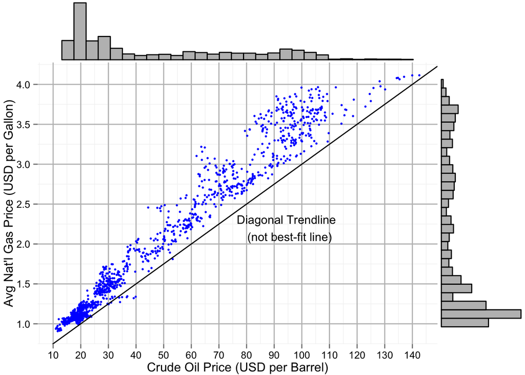

Something interesting pops up here: we see that owners of gas stations will not drop the price of gas below a certain number that follows a “trend line” roughly captured by the diagonal line, which itself is a function of oil price. The “trend line” is probably the break-even price gas stations buy gasoline at, or cost of production and distribution for gas stations owned by refiners. But, here’s the interesting part, gas station owners will happily up-charge you for gasoline. This can be clearly seen by frequent deviations above the diagonal line but seldom below it! Why am I not surprised ? :-)

# Correlation of the Change in Oil and Gas Prices

```
## stat_bin: binwidth defaulted to range/30. Use 'binwidth = x' to adjust this.
## stat_bin: binwidth defaulted to range/30. Use 'binwidth = x' to adjust this.
## stat_bin: binwidth defaulted to range/30. Use 'binwidth = x' to adjust this.
```

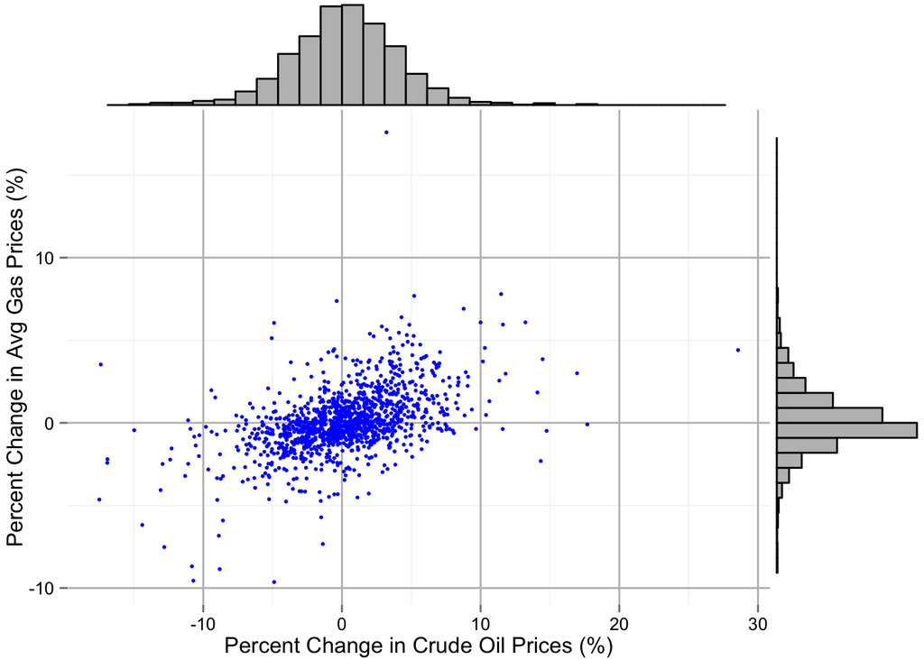

However, one of the reasons, which deserve some merit, as to why the correlation is lower, is that we are using weekly data when we know oil prices change daily and gas stations owners don’t have to abide by weekly changes in gas prices. Also, we had to lag crude oil prices by 3 days since they are reported on Fridays and gas prices are reported on Mondays. Obviously, during the weekend, oil prices might have changed and gas prices could have adjusted accordingly and our data would capture the change in gas prices but would miss out on any change in oil prices that would have occurred during the weekend.

Another interesting plot to look at is a correlogram by lagging the change in average gas prices against the change in oil prices.

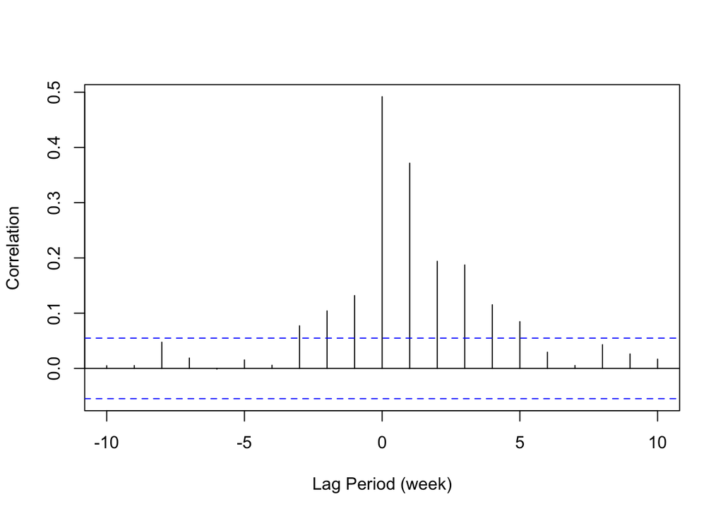

correlogramIn this correlogram, the change in average gas prices were lagged by one period at a time then the correlation computed against change in crude oil prices for each lagged period.

The results are actually quite interesting. There is still a decent correlation up to 3 weeks after a change in oil price is observed but the correlation quickly diminishes beyond that.

# Conclusion

Yes changes in gas prices are correlated with changes in oil prices to a certain extent. Keep in mind, these are average gas prices across the U.S. so the findings in this post might not necessarily translate to the gas station across the street from your place.